# Random Forest - Climate Data Analysis

Contributors: Joey Hulbert,…

| [Redcedar](https://jmhulbert.github.io/open/redcedar) | [Data](https://jmhulbert.github.io/open/redcedar/data) | [Analyses](https://jmhulbert.github.io/open/redcedar/analyses) | [Instructions](https://jmhulbert.github.io/open/redcedar/instructions) |
| --- | --- | --- | --- |

> Please note this analysis and R Markdown document are in still in development :)

# Approach

The overall approach is to model empirical data collected by community scientists with ancillary climate data to identify important predictors of western redcedar dieback.

## iNat Data - Empirical Tree Points

The steps for wrangling the data are described [here](https://jmhulbert.github.io/open/redcedar/data).

### Wrangle data into format for climateNA

Data were then subset to include only gps information to use in collecting ancillary data.

### Normal Data

Climate data then extracted with ClimateNA tool following the below process. Data were downloaded for the iNat GPS locations using the ClimateNA Tool.

ClimateNA version 7.40 -

- Climate data extraction process with ClimateNA
  - Convert data into format for climateNA use (see above)
  - In ClimateNA
    - Normal Data
      - Select input file (browse to gps2232 file)
      - Choose ‘More Normal Data’
        - Select ‘Normal_1991_2020.nrm’
      - Choose ‘All variables(265)’
      - Specify output file
- Grouping explored
  - data averaged over 30 year normals (1991-2020)

## Variables

- Response variables included in this analysis
  - Tree canopy symptoms (binary)
- Explanatory variables included
  - Climate data
    - 30yr normals 1991-2020 (265 variables - annual, seasonal, monthly)

Then, remove specific climate variables not useful as explanatory variables (e.g. norm_Latitutde)

Remove variables with variables that have near zero standard deviations (entire column is same value)

#### Normal Model

```
##
## Call:
##  randomForest(formula = reclassified.tree.canopy.symptoms ~ .,      data = combo.filtered.nearzerovar, ntree = 2001, importance = TRUE,      proximity = TRUE, na.action = na.omit)
##                Type of random forest: classification
##                      Number of trees: 2001
## No. of variables tried at each split: 14
##
##         OOB estimate of  error rate: 43.43%
## Confusion matrix:
##                 Dead Top Healthy Other Thinning Canopy Tree is Dead class.error
## Dead Top              68     116    24              35           16   0.7374517
## Healthy               53    1027    83              80           32   0.1945098
## Other                 19     156    63              30            9   0.7725632
## Thinning Canopy       32     153    31              85            8   0.7249191
## Tree is Dead          21      52     6              12           18   0.8348624
```

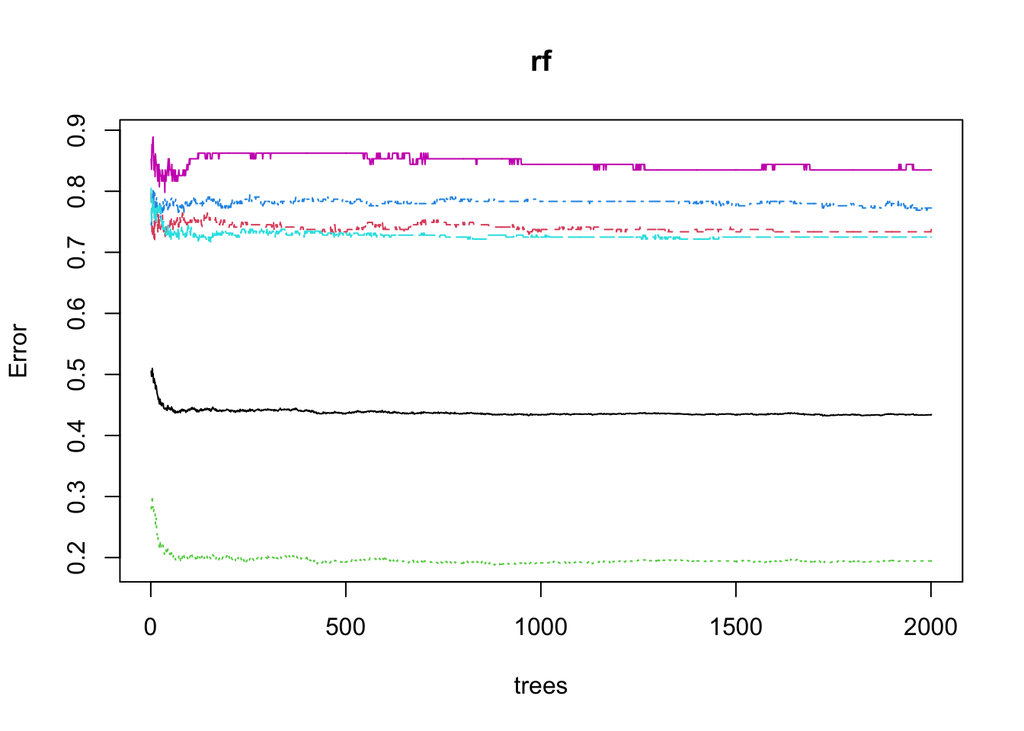

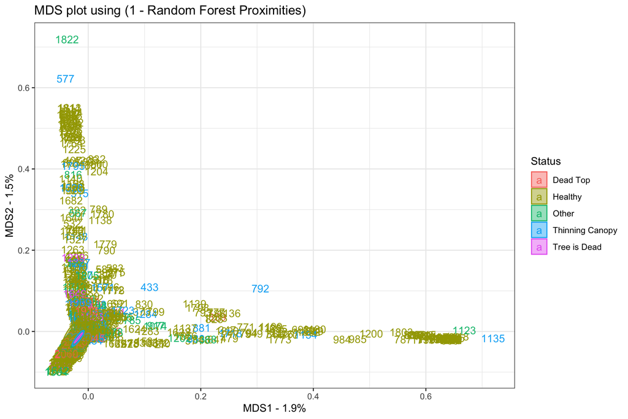

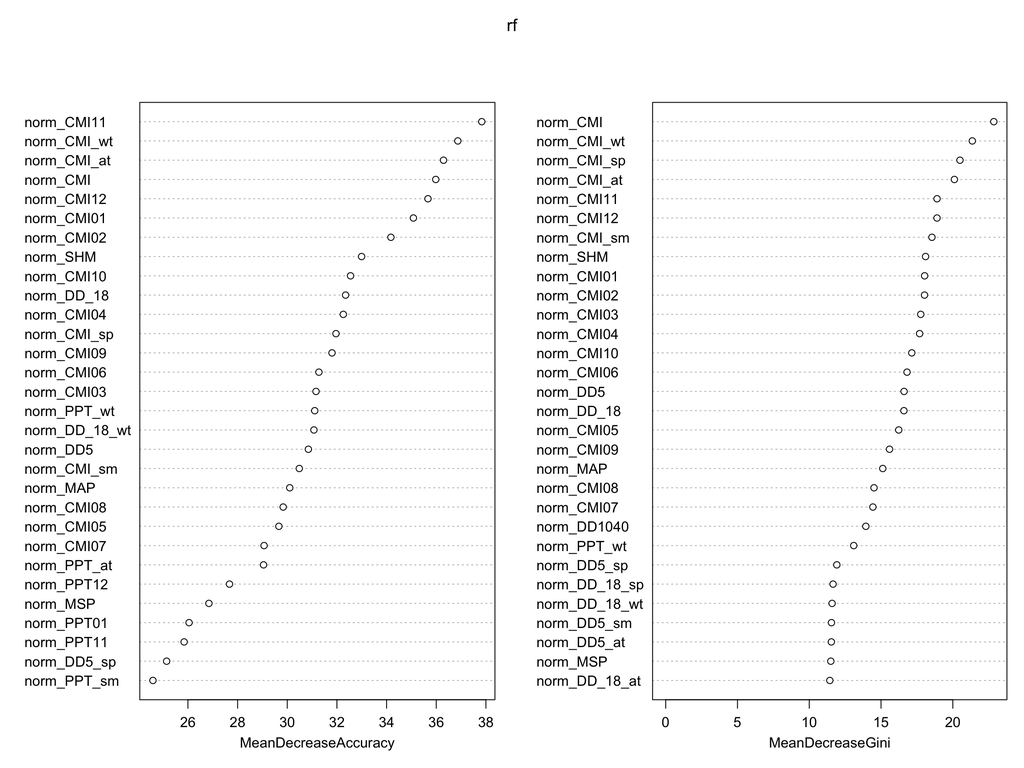

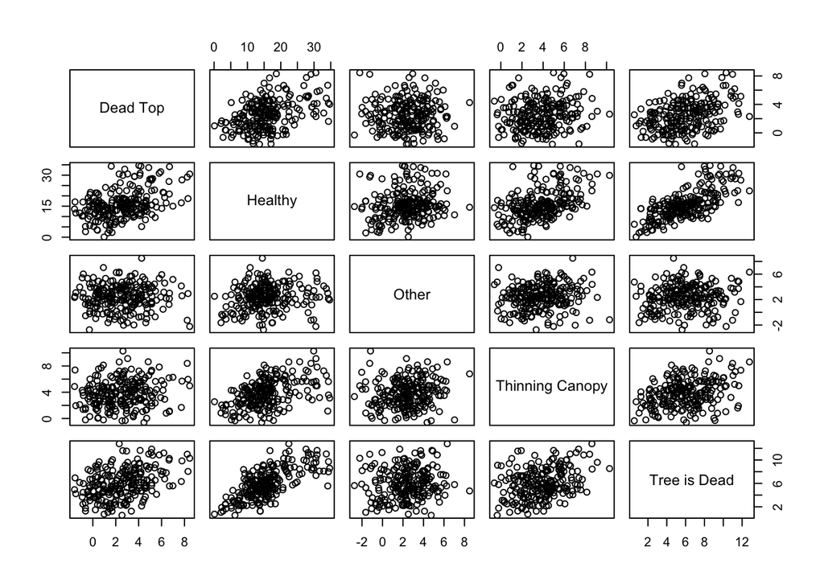